# Microphone

Modified

Mo 2023-04-24 09:54

## Activity Objective

- Implement a microphone in a circuit to interface with the Arduino
- Collect microphone data
- Measure your reaction time with the snap_snap.ino sketch

## Activity Procedure

1. Review Microphone Basics before proceeding.
2. Construct the microphone circuit shown below. Make sure to take note of the correct orientation of the microphone. The ground pin of the microphone needs to the ground of the circuit.

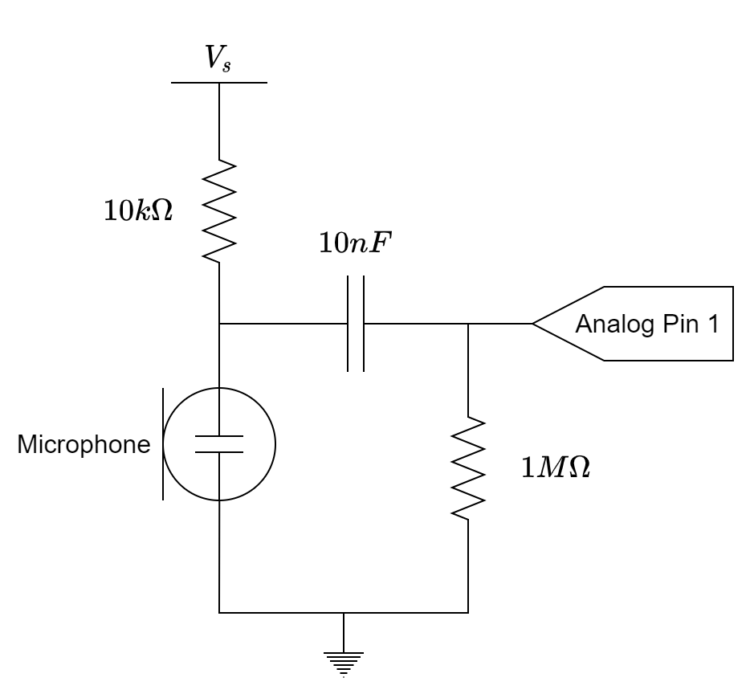

3. Take the sketch serial_data.ino and comment out the first two print statements. These statements are the `Serial.print(millis());` and `Serial.print(',');` lines.
4. Upload the modified serial_data.ino sketch to the Arduino.
5. Open the Arduino IDE serial plotter (note, not the serial monitor). This may be found by going to `Tools > Serial Plotter` or using the keystrokes `<ctrl>+<shift>+L`. If your version of the Arduino IDE is older than 1.6.6, you will not have the serial plotter feature. You must upgrade your Arduino IDE to obtain this feature.
6. Raise your hand and show the instructor your setup.
7. Download the snap_snap.ino sketch and upload it to your Arduino.
8. Open the Arduino IDE serial monitor. The snap_snap.ino sketch measures your reaction time using the microphone. The goal is to snap or make a sound as quickly as possible after the serial monitor tells you to go. If the serial monitor shows your reaction time as being less than approximately 50 milliseconds, your circuit is likely incorrect. Double-check your circuit and make sure everything is wired correctly.
9. Record your best reaction time out of ten tries. Let your instructor know your best reaction time.